# Lecture 2: 1D Kinematics

Kinematics describes the motion of an object without looking at it's underlying causes. We'll come back to those causes (forces) when we start to study [dynamics](https://en.wikipedia.org/wiki/Dynamics_%2528mechanics%2529) from Lecture 5 onwards.

## Reference Frames

When we consider motion we always consider the motion of objects in a reference frame, or coordinate system. An appropriate choice of coordinate system can help enormously in solving a problem.

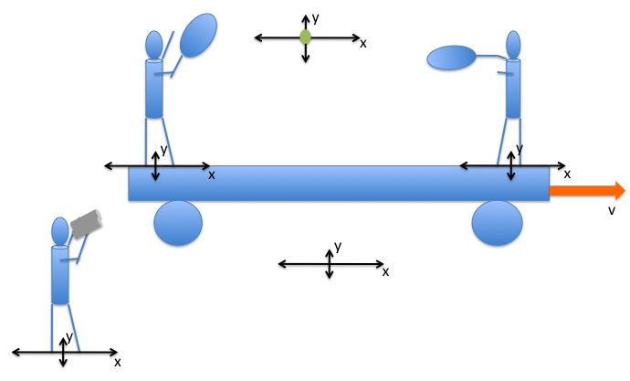

## Displacement

We need a quantity to express the position of an object. The displacement of an object is a vector which points from the origin of the coordinate system to the object. For now we'll deal with 1 dimensional displacement.

We should also consider the relative displacement of one object from another, or of an object from a position it occupied at an earlier time.

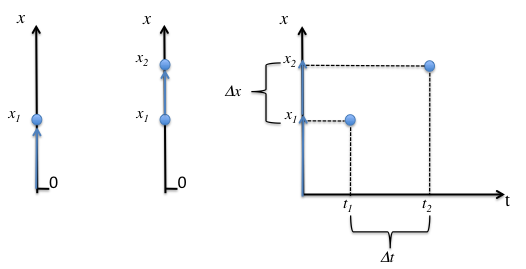

Note that the displacement of an object is not necessarily the same as the distance

[figure not shown]

it has traveled!

## Average Velocity

If we denote the displacement from a point at time $t_{1}$ as $x_{1}$ and at time $t_{2}$ as $x_{2}$ the change in the displacement in the time interval $\Delta t=t_{2}-t_{1}$ is $\Delta x = x_{2}-x_{1}$.

The average velocity in this time interval is

$\large \bar{v}=\frac{\Delta x}{\Delta t}$

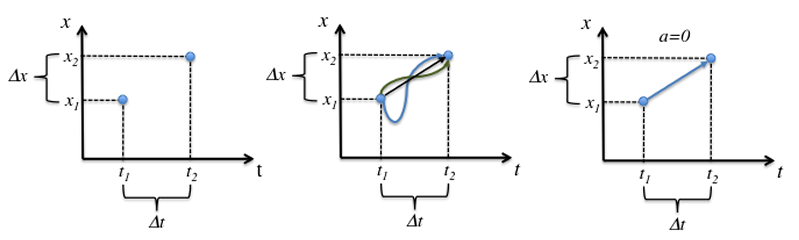

## Instantaneous Velocity

The instantaneous velocity is found by taking the limit as $\Delta t\to 0$

$\large v=^\lim_{\Delta t\to0} \frac{\Delta x}{\Delta t}=\frac{dx}{dt}$

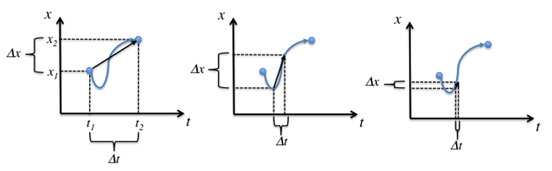

Note that the velocity is the **slope** of the interval, not the length of the arrow!

## Acceleration

In the same way as velocity is the rate of change of displacement acceleration is the rate of change of velocity

Average acceleration is

$\large \bar{a}=\frac{\Delta v}{\Delta t}$

The instantaneous acceleration is found by taking the limit as $\Delta t\to 0$

$\large a=^\lim_{\Delta t\to0} \frac{\Delta v}{\Delta t}=\frac{dv}{dt}=\frac{d^2x}{dt^2}$

## Movement in different reference frames

In classical physics we can easily transform the displacement, velocity and acceleration from one reference frame to another, using [Galilean transformations](https://en.wikipedia.org/wiki/Galilean_transformation) (i.e. just subtract the motion of the reference frame from the motion of the object.)

For example, if I am running at 10km/h (relative to a stationary observer), past someone who is running at 9km/h, my relative velocity to the other person, or, my velocity in their reference frame is 10km/h - 9km/h = 1 km/h.

We should be mindful that **all these quantities are vectors**, in our next lecture we will look at how to deal with relative motion in more than one dimension.

Relativity, which we will not be covering in this course, results in a different set of transformations, because in this theory light moves at the same speed in all reference frames. At speeds much less than the speed of light the mathematical limits of relativistic transformations are the same as the Galilean transformations.

## Equations of Motion Using Calculus

If the acceleration is a constant $a$ which does not change with time then we can say at a time $t$

$\int^{v(t)}_{v_0}\,dv= v(t)-v_0=\int^{t}_0 a\,dt = at$ where $v_{0}$ is the velocity at $t=0$.

so $v= v_{0}+at$

and similarly

$\int^{x(t)}_{x_0}\,dx= x(t)-x_0=\int^{t}_{0} v\,dt = v_{0}t+\frac{1}{2}at^2$

so $x= x_{0}+v_{0}t+\frac{1}{2}at^2$

## Equations of Motion without time

To find a relation between acceleration and velocity that does not include time

$\large a=\frac{dv}{dt}=\frac{dv}{dx}\frac{dx}{dt}=v\frac{dv}{dx}$

$\large \int^{x}_{x_{0}}a\,dx=\int^{v}_{v_{0}}v\,dv$

$\large a(x-x_{0})=\frac{1}{2}(v^2-v_{0}^2)$

$\large v^{2}=v_{0}^2+2a(x-x_{0})$

## Equations of Motion

As you can see the equations of motion you have probably seen before are simply a result of calculus!

$\large v= v_{0}+at$

$\large x= x_{0}+v_{0}t+\frac{1}{2}at^2$

$\large v^{2}=v_{0}^2+2a(x-x_{0})$

## Objects in free fall

Galileo made a remarkable observation that close to the Earth the acceleration due to gravity is a constant for all objects. Therefore in the absence of air resistance freely falling objects are well described by the equations of motion we just derived.

His observation was especially remarkable given his lack of accurate measurement tools. Today we can do actually do extremely accurate measurements with everyday devices that you may already own!

### Video Analysis of Free fall

By taking a video of a freely falling object and processing it so that we can see the position of the object in each frame (which at 30 frames per second is every 0.033 seconds) we can analysis the motion of the object.

### Non Constant Acceleration

Through the use of integral calculus we are not restricted to dealing with simple situations in which acceleration is constant with time. In the same was as we derived the equations of motion we can take any arbitrary function which describes acceleration with time, $a(t)$ and integrate it to find the velocity.

$v(t)=v_{0}+\int^{t}_{0}a(t)\,dt$

Note that if we know the velocity at a different time than $t=0$ we can also integrate from that time instead.

similarly for displacement

$x(t)=x_{0}+\int^{t}_{0}v(t)\,dt$

### Accelerometers

Most smartphones include accelerometers to be able to detect motion and there apps available which provide access to their readouts.

### Software

Sometimes a function will be complicated to integrate analytically, or in the case of experimental data, we may not actually know the function $a(t)$. In these cases numerical integration is useful. Mathematics packages, such as Mathematica or Matlab that can help you do this are available for free to Stony Brook students.

We of course can always use python and this is why I like to set python as the basic programing element of this course.

```python
from IPython.display import Video

video_path = 'v1.mov'
Video(video_path)
```

[video not shown]

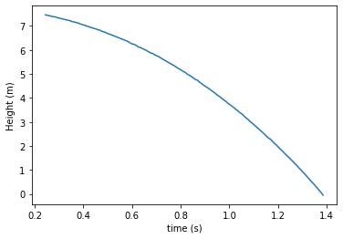

```python
import numpy as np
import matplotlib.pyplot as plt
data = np.loadtxt("Data/v1.dat")
plt.plot(data[:,0],data[:,1])
plt.xlabel("time (s)")
plt.ylabel("Height (m)")
```